## Практична робота №3.Алгоритми сортування та їх складність.Порівняння алгоритмів сортування

# Мета : Опанувати основні алгоритми сортування та навчитись методам аналізу їх асимптотичної складності.

# 1 . Вивчити самостійно і записати (будь-яким способом) алгоритм бульбашкового сортування. Оцінити асимптотику алгоритму сортування методом бульбашки в найгіршому і в найкращому випадку. Порівняти за цими показниками бульбашковий алгоритм з алгоритмом сортування вставлянням. Чому на практиці бульбашковий алгоритм виявляється менш ефективним у порівнянні з сортуванням методом зливанням?

```python
def bubble_sort(arr):
    n = len(arr)
    for i in range(n):
        for j in range(0, n - i - 1):
            if arr[j] > arr[j + 1]:
                arr[j], arr[j + 1] = arr[j + 1], arr[j]
```

Через різницю в асимптотичній складності , в найгіршому випадку у бульбашки це O(n^2) , а у злиття це O(nlog n).Бульбашку можна використовувати якщо кількість даних які потрібно обробити невелика , але вже з великим об'ємом даних будуть проблеми , бо час затрачений на це буде дуже великим , а при використанні зливання буде все значно швидше(він розбиває задачі на підзадачі та потім збирає їх)

# 2 . Оцінити асимптотичну складність алгоритму сортування зливанням, скориставшись основною теоремою рекурсії.

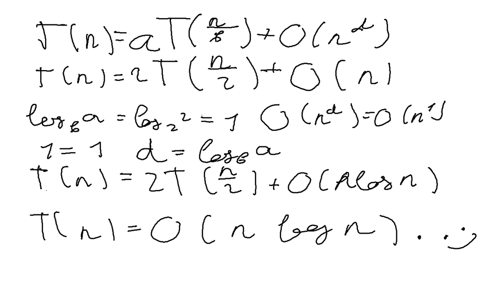

O(nlog n) у всіх випадках.

# 3 . Вивчити і записати (будь-яким способом) самостійно алгоритм швидкого сортування. Оцінити асимптотичну складність алгоритму швидкого сортування, скориставшись основною теоремою рекурсії.

```python
def quicksort(arr):
    if len(arr) <= 1:
        return arr

    pivot = arr[len(arr) // 2]
    left = [x for x in arr if x < pivot]
    middle = [x for x in arr if x == pivot]
    right = [x for x in arr if x > pivot]

    return quicksort(left) + middle + quicksort(right)
```

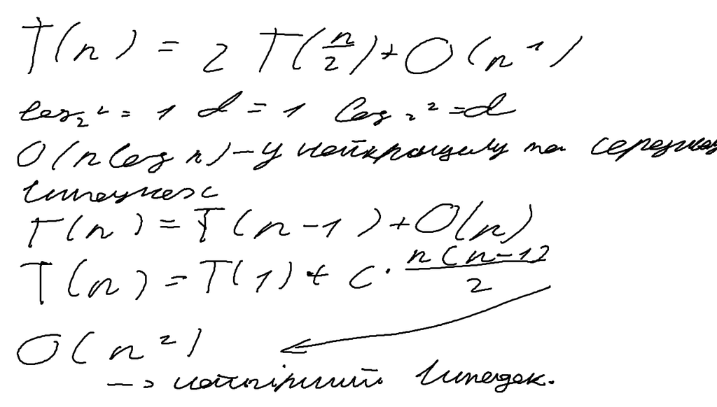

У найгіршому випадку асимптотична складність O(n^2).У найкращому та середньому O(nlog n).

# 4 . Контрольні питання.

- Що таке асимптотична складність алгоритму сортування і чому вона важлива для порівняння алгоритмів? - Асимптотична складність алгоритму сортування — це спосіб описати, як час виконання або обсяг пам'яті, необхідний для алгоритму, зростає зі збільшенням розміру вхідних даних.
- Які алгоритми сортування мають квадратичну складність у найгіршому випадку? Поясніть, чому це може бути проблемою для великих обсягів даних. - Сортування бульбашкою , сортування вставкою.Квадратична складність алгоритму означає , що час виконання алгоритму зростає пропорційно квадрату кількості елементів у списку.Для великих обсягів даних це може призвести до неприйнятно тривалого часу виконання.
- В чому полягає перевага сортування злиттям над сортуванням вставками для великих наборів даних? - швидкість у великих обсягах даних , тому що сортування злиттям має асимптотичну складність O(nlog n), а сортування вставкою O(n^2).
- Які алгоритми сортування використовуються для сортування списків у стандартних бібліотеках мов програмування, таких як Python, Java або C++? - TimSort(Python),Introsort(C++),Dual-Pivot Quicksort(Java).
- Яка різниця між алгоритмами сортування злиттям і швидким сортуванням? У яких випадках краще використовувати кожен з цих алгоритмів? - Сортування злиттям гарантує O(n log n) складність, розбиваючи та зливаючи відсортовані частини, що ефективно для великої кількості даних. Швидке сортування, в середньому, також O(n log n), але може мати O(n^2) в гіршому випадку, хоча на практиці воно часто швидше, особливо для "на місці" сортування. Сортування злиттям стабільніше за швидке.
- Які фактори слід враховувати при виборі алгоритму сортування для конкретної задачі? - об'єм даних , точність , швидкість.

# 5 . Висновки.

На цьому практичному занятті ми опанували основні алгоритми сортування та навчились методам аналізу їх асимптотичної складності.